# The Sustenance-Capacity Corpus — a Map, and an Invitation

For Julio Huato

Author

Carlos Galindo Escajeda

For circulation

July 7, 2026

Welcome to co-authorship in any of the papers below.

The door is open on each of the pieces marked *Carlos* — those need “tough love” and a second author who will engage constructively and with feasible positive feedback (and not obstruct the wheels of progress). What follows is a map of the whole thing, then a one-screen brief on each of the new pieces — what it is, what is banked, what is missing, and where it is meant to go. The statuses of your book and the two joint papers are collected in an appendix at the end. Pick whatever you want a hand in.

The one idea under all of it is yours: that the value of wealth and the rate of interest have a material anchor in the reproduction of the working population, and that the allocation of productive activity and the valuation of the resulting wealth are a single duality. Everything here is either that idea, a formalisation of it, or an application of it — so, before anything else, thank you. The reproduction anchor that SCN only makes formal, and the fictitious-capital form of wealth, are yours; almost everything else on the map is that seed’s offspring — leaning on your idea directly — or a cousin that leans on it through one of them.

## The map

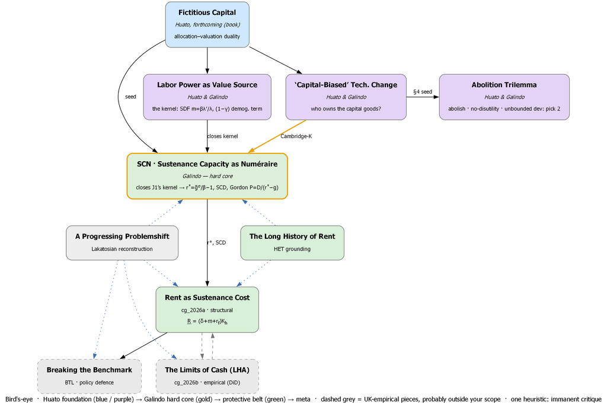

Figure 1

The structure is deliberately Lakatosian: a **hard core** (sustenance capacity as the numéraire of value, and a dominance criterion that replaces Pareto efficiency), a **protective belt** of applications that take the empirical risk, and a single **positive heuristic** — immanent critique. Your book is the seed; the two value-theory joint papers and the trilemma are the bridge; SCN is the hard core, and the belt is what the idea pays out.

# The hard core

## *Sustenance Capacity as Numéraire* (SCN)

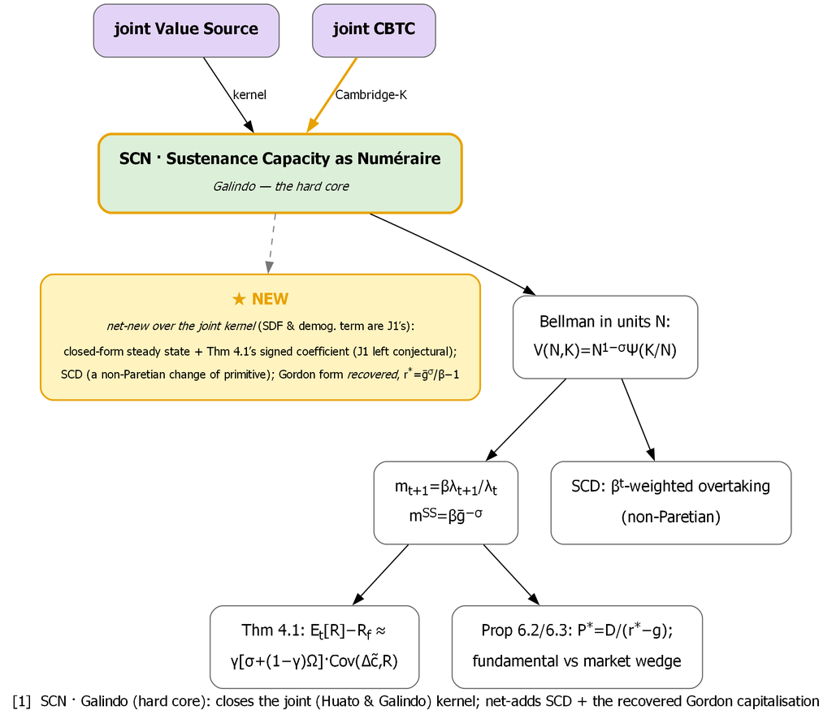

*The method in miniature.* The capitalisation is immanent critique made concrete: the very no-arbitrage recursion $P_t=\mathbb{E}_t[m_{t+1}(D_{t+1}+P_{t+1})]$ the mainstream uses, iterated under the sustenance-grounded steady-state kernel, *recovers* $P=D/(r^*-g)$ — deriving from the sustenance problem the discount rate the textbook posits from time-preference. This is the formal, fully *stochastic* kernel paper (a derived stochastic discount factor, a stochastic steady state).

*The pitch.* The anchor is now checkable: the risk-premium coefficient the joint paper left for future work is a signed closed form, and the attribution note fixes the kernel’s credit to the joint work in print. It goes to *Metroeconomica* because Kurz and Salvadori edit it: the von Neumann school judging a von Neumann-lineage primitive.[^1] Once published, everything on this map — your book included — can point to a refereed foundation instead of a manuscript, and every reader the paper persuades has accepted the book’s kernel before ever meeting the book.

## What the SCN paper does to your idea — and why

My ‘belief’: A reader who accepts this paper on internal consistency has accepted, under neutral names, the kernel of your book and the joint papers unknowingly. This I believe can help rather than hinder your crusade (no such thing as bad publicity!): reproduction of the working population as the anchor of value, an interest rate with a material ground, prices measured against a reproduction fundamental, competitive markets compounding the reproduction deficits of the capital-poor. Whoever grants that and later meets the same structure in its own vocabulary can reject it only by admitting the objection was to the words. Sraffa ran the same play — the book that broke marginal capital theory names no Marxian category, and the school it built now edits the journal this paper goes to. Your book and the joint papers keep their own vocabulary; the renaming lives only in SCN. Not a conversion — the door held open from the inside.

No entirely free lunch: The paper dresses the kernel in a recursive Bellman model, aggregate capital, marginal factor pricing, a smooth Cobb–Douglas technology. It renames the primitive — labour power becomes sustenance capacity. It foregrounds a von Neumann/classical-surplus lineage over a Marxian one, and it goes to a journal that is not Marxist. These are real departures, but **I think it will be a ‘real score’, if you do not preach to the choir**.

At *Metroeconomica*, Kurz and Salvadori’s referees will probably press the purist objection: von Neumann runs on fixed coefficients and inequalities, while a smooth one-sector technology and aggregate capital are orthodox constructions — so the kinship holds for the primitive, labour power as a produced magnitude, not for the technology’s form. The welfare result — the permanent, compounding reproduction deficit of capital-poor dynasties — runs on monotone accumulation under common prices, an engine that needs neither smooth substitution nor aggregate capital. But I have only proved it one-sector. A multi-sector version I have pre-envisioned already — but that is too much for the moment; perhaps a distant-future paper.

# The protective belt

## *Rent as Sustenance Cost*

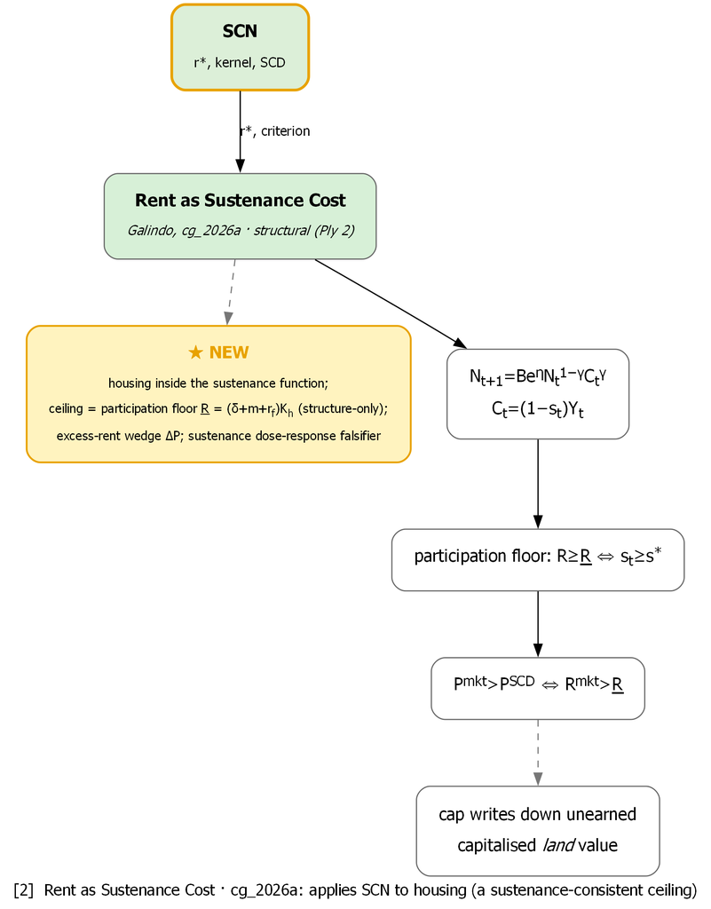

- **What.** SCN applied to housing: a sustenance-consistent rent ceiling $\underline{R}=(\delta+m+r_f)K_h$, an excess-rent wedge $\Delta P$, and a sustenance dose-response as the front-line falsifier.
- **Why.** To turn the abstract dominance criterion into a concrete housing benchmark with a real test.
- **So what.** The criterion becomes computable on housing: a ceiling anchored in replacement cost rather than posited, and the excess of market rent over it read as the location rent on land.
- **Banked.** The ceiling derivation; a transparent back-of-envelope that motivates the overvaluation premise from UK data.
- **Missing.** The empirical adjudication (delegated to the LHA paper); three parameters still to be calibrated.
- **Venue.** *Cambridge Journal of Economics*.

*Note.* The SCD-consistent price $P^{SCD}=\underline{R}/(r-g_R)$ is SCN’s capitalisation applied to rent — the kernel’s steady-state reduction, *not* an imported Gordon identity (and, the structure being a produced good, that benchmark is its replacement cost $K_h$ by free entry, so the overvaluation $R^{\mathrm{mkt}}>\underline{R}$ is rate-cancelling and well-posed even where a naive Gordon level would diverge — the divergence then marks binding land scarcity, not a flaw). Unlike SCN, this paper carries its argument in deterministic main text, with the stochastic kernel relegated to an appendix.

## *The Long History of Rent*

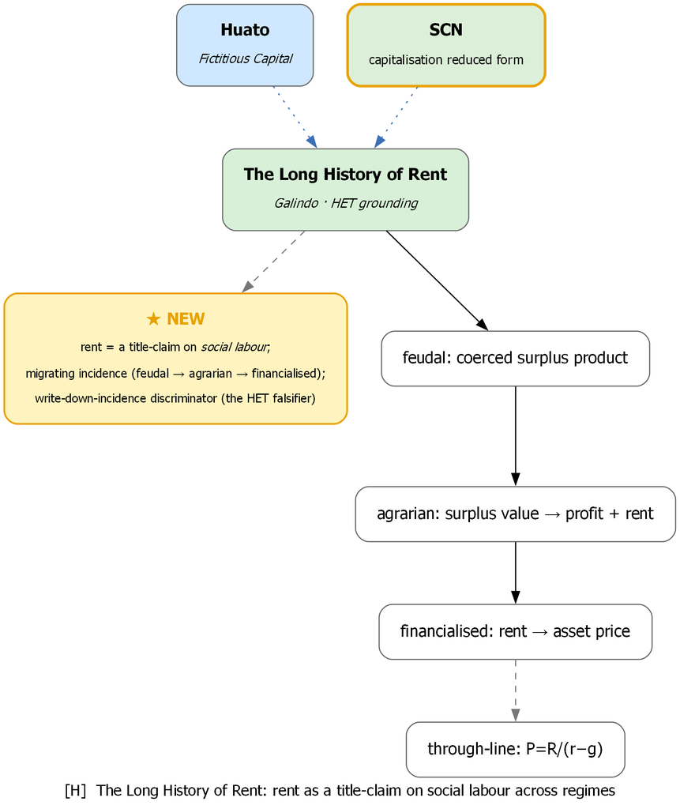

- **What.** Eight centuries of rent, from coerced surplus to capitalised claim: rent as a title-claim on social labour, its incidence migrating across regimes, and the capitalisation $P=R/(r-g)$ as the technical through-line.
- **Why.** To show that “economic rent” is a historical product, not a natural fact — and that the through-line links the classical theory of land value to the modern asset-pricing of housing.
- **So what.** Eight centuries of evidence for the programme’s central object: the title-claim persists across every regime examined while its incidence migrates — the modern capitalised claim an instance, not an anomaly.
- **Banked.** The genealogy; the migrating-incidence thesis (falsifiable on stated terms, and not falsified by any regime examined).
- **Missing.** A formal model of how tenure inequality compounds — the one open conjecture, stated as such.
- **Venue.** *Cambridge Journal of Economics* / *Review of Radical Political Economics*.

## *The Limits of Cash* — the LHA study

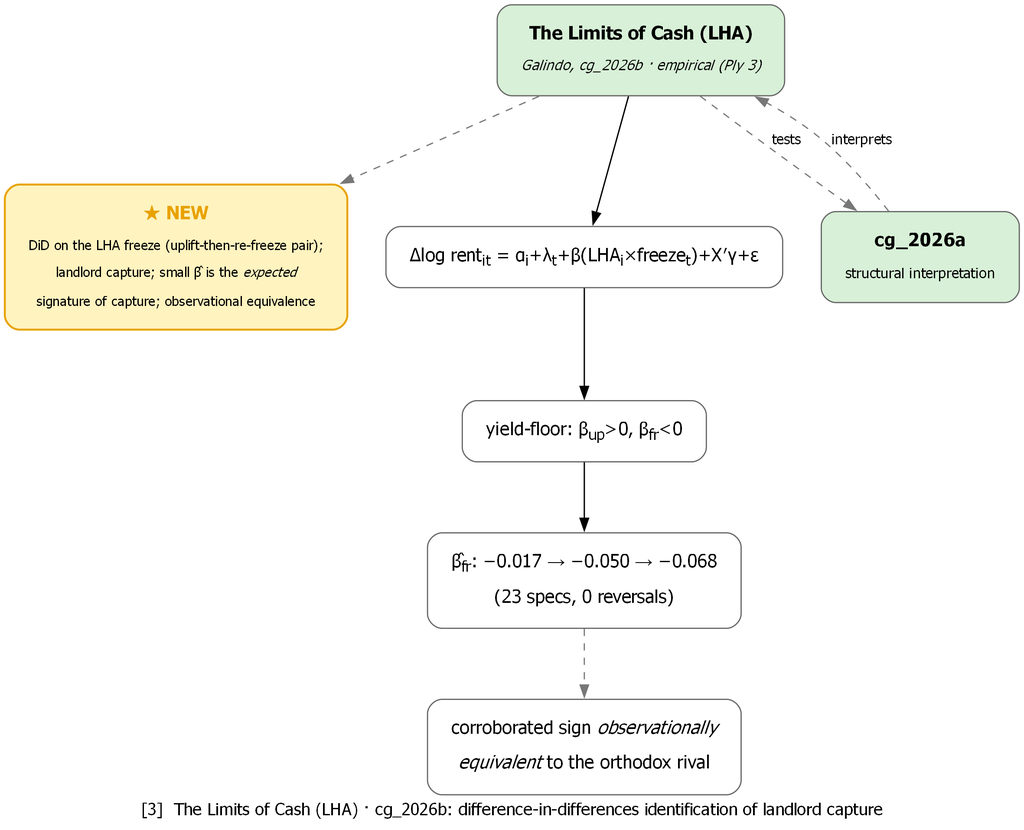

- **What.** A difference-in-differences study of the Local Housing Allowance freeze: how much housing benefit is captured by landlords as rent rather than reaching tenants.
- **Why.** It is the empirical risk the programme takes — a falsifiable prediction with a clean natural experiment.
- **So what.** The empirical leg. Its corroborated prediction is shared with the orthodox account — the paper says so, and names the structural restriction that would separate them.
- **Banked.** The capture sign and its robustness; a bias-toward-zero inference posture.
- **Missing.** The structural over-identifying test that would separate the lenses (needs cohort micro-data).
- **Venue.** A housing- or social-policy empirical journal.

## *Breaking the Benchmark* — the rent-regulation defence

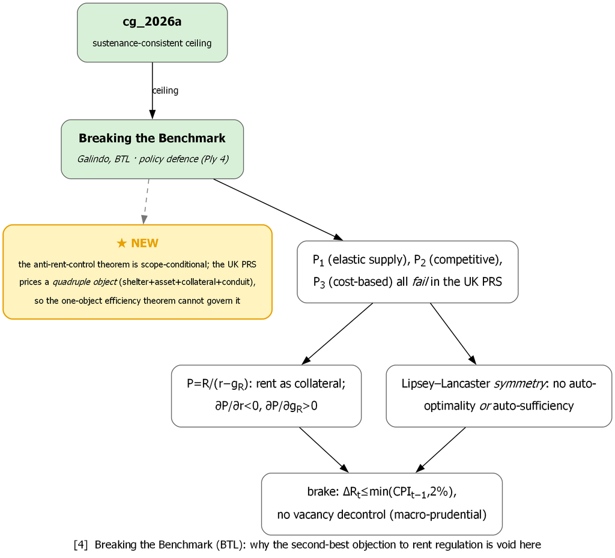

- **What.** The textbook veto on rent regulation is scope-conditional. The UK private rented sector prices a *quadruple object* — shelter, capitalised asset, credit collateral, fiscal conduit — so the one-object efficiency theorem cannot govern it.
- **Why.** To neutralise the orthodox veto using the orthodox toolkit (Lipsey–Lancaster second best) and supply the formal apparatus the applied policy work lacks.
- **So what.** Removes the automatic efficiency objection to a rent brake.
- **Banked.** The scope-conditional argument; the second-best symmetry result; the quadruple-object diagnosis and the capitalisation channel.
- **Missing.** Three uncalibrated magnitudes — the economic-rent share, the landlord-exit elasticity, and the search-and-bargaining markup over competitive rent (the paper’s P2).
- **Venue.** A policy / heterodox journal.

## Two more, briefly

- *Did Higher Interest Rates Raise Rents?* — a user-cost pass-through test of whether monetary tightening fed into rents; a self-contained empirical piece adjacent to the belt. *Venue: a monetary / applied economics journal.*
- *A Progressing Problemshift* — a Lakatosian reconstruction of the programme as a whole, asking not whether it is *true* but whether its development is *progressive*. *Venue: a methodology / history-of-thought journal.*

# The Abolition Trilemma — new joint work (companion to CBTC)

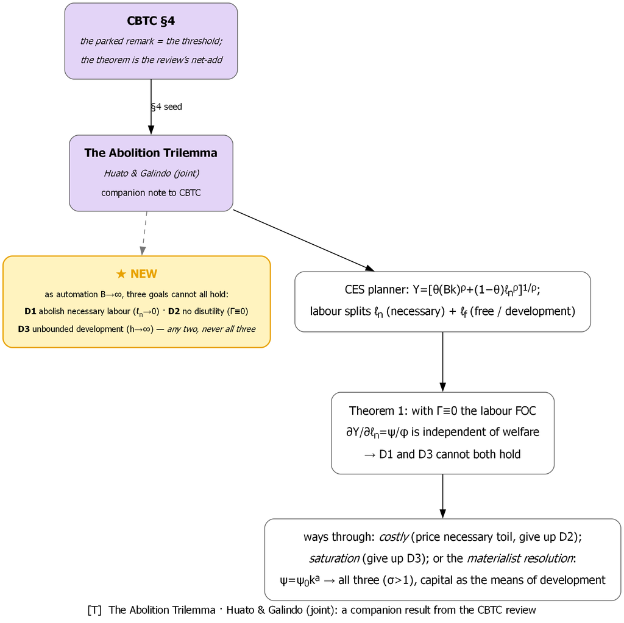

- **What.** A new impossibility theorem, grown from a remark your CBTC §4 set aside. As automation rises without bound, three goals cannot hold together — **abolish** necessary labour, charge it **no disutility**, keep development **unbounded**: any two, never all three.
- **Why.** You wrote that minimising labour “would require saturation or concavity… at the cost of the unbounded growth in human development obtained here,” and parked it. The review picked the remark up and made it a theorem; this companion formalises it.
- **So what.** Prices the abolition debate: through the output channel every programme surrenders one of the three (Theorem 1); the *materialist resolution* (Theorem 3) is the exit — free-time productivity scaling with the capital base delivers all three for $\sigma>1$, capital becomes the means of development.
- **Banked.** The steady-state impossibility theorem; the two escape routes (*costly*: price necessary toil; *saturation*: bound development); the materialist resolution (all three, $\sigma>1$; survives heterogeneous capital).
- **Missing.** The dynamic case; a welfare ranking of the two routes.
- **Venue.** A companion note alongside CBTC, or a standalone short theory paper.

# The invitation, plainly

| Paper | Status |
| --- | --- |
| *Fictitious Capital* | your book |
| *Labor Power as Value Source* | joint · in review (MRP) |
| *“Capital-Biased” Technical Change* | joint · in review (SUFE) |
| Abolition Trilemma | joint |
| SCN | Carlos |
| Rent as Sustenance Cost | Carlos |
| The Long History of Rent | Carlos |
| The Limits of Cash (LHA) | Carlos |
| Breaking the Benchmark (BTL) | Carlos |

What I’d ask of you is the thing you do best: think the issues through to their joints, and see how the pieces bear on one another — you read the architecture of this more clearly than anyone. Find the gotchas — where an argument is wrong, or only brittle, name it; and where it can be made stronger, point me to the feasible next step.

The two UK-empirical pieces — *The Limits of Cash* and *Breaking the Benchmark* — are probably outside your scope; the rest is squarely the kind of question you think about. And on any piece you’d like your name on, say the word and it becomes ours.

SCN is open too; it is only the one already queued for *Metroeconomica*, so if you want your name on it, that is easier before it goes than after.

# Appendix — your foundation, for the record

Where each stands, and what the corpus draws from it.

## *Fictitious Capital: The Form and Flow of Capitalist Wealth* — your book

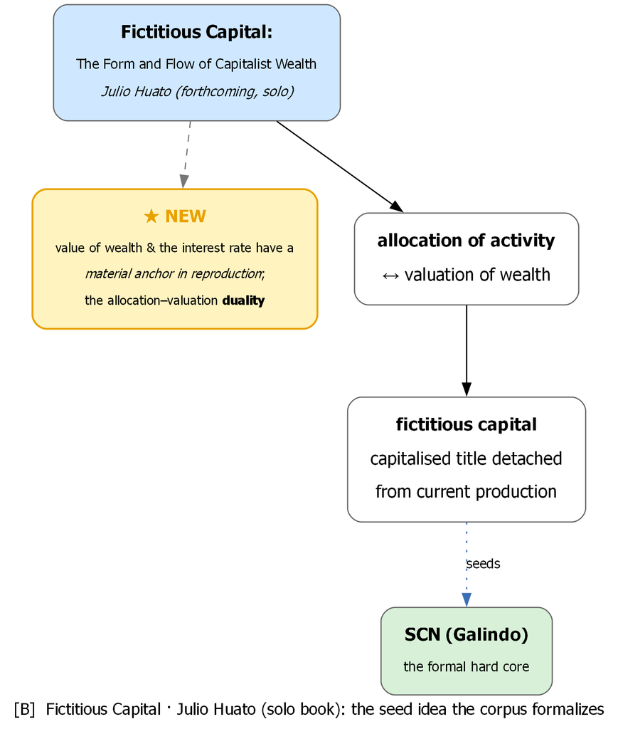

- **In the map.** The seed: every paper in the corpus either formalises this book’s anchor or applies it, and cites it as the origin.
- **What the corpus needs from it.** A circulating, citable version — the papers lean on it, and a reader cannot yet check the imports.
- **Venue.** A monograph; its foundational-article form is the joint *Labor Power as Value Source*, next.

## *Labor Power as Value Source and the Form of Capitalist Wealth* — joint

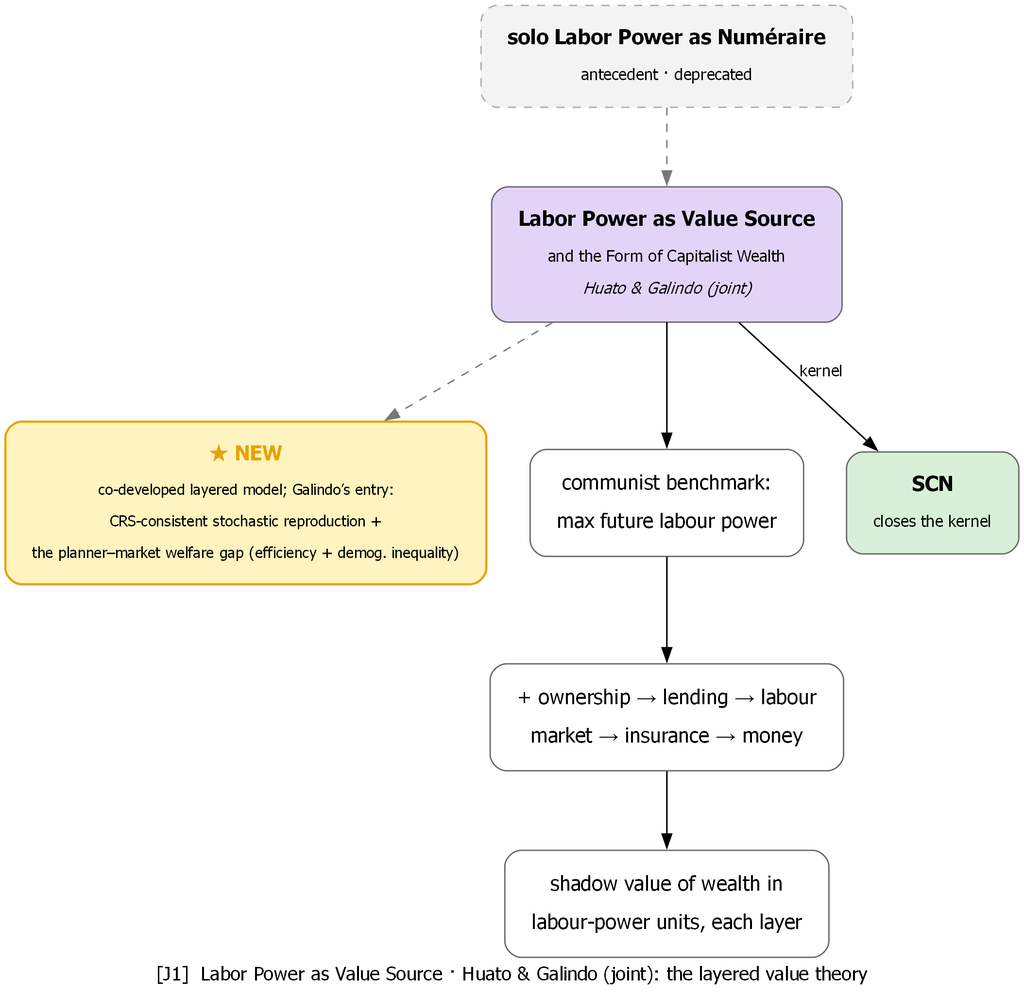

- **In the map.** The bridge from the book to the formal kernel: the labour-power discount factor and the demographic-continuation term live here, with CRS-consistent stochastic reproduction and the planner–market welfare gap. SCN takes exactly this kernel and closes it — the closed forms are SCN’s; the kernel is this paper’s.
- **Missing.** A last polish — under way.
- **Venue.** With Monthly Review Press; Brill or Verso if it is declined. Submitted, and still being polished in parallel — awaiting their decision.

## *“Capital-Biased” Technical Change: Who Owns the “Capital Goods”?* — joint

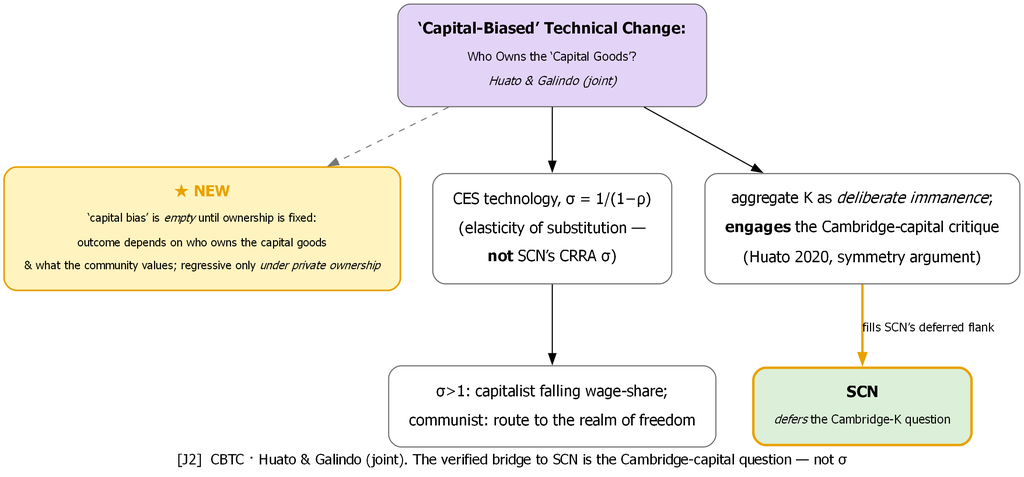

- **In the map.** The corpus’s one direct engagement with the aggregation question the hard core defers — aggregate capital held as deliberate immanence, the Cambridge critique met with the symmetry argument — and the seed of the trilemma in the main text (its §4 remark).
- **Missing.** Referee reports — it is with the journal now.
- **Venue.** Submitted to the SUFE journal (Shanghai University of Finance and Economics); awaiting referees.

## Footnotes

[^1]: The descent is of the *primitive* — labour-power as a produced magnitude — not of the technology’s form. Von Neumann’s system runs on fixed coefficients and inequalities; the smooth CRS map, aggregate capital, and marginal pricing are the orthodox chassis the paper adopts on purpose.